*Energy Star Score Prediction for NY Buildings*

**Data Importing**

```r
# Importing the required libraries
library(Hmisc)
library(caret)
library(corrplot)
library(Metrics)

memory.limit()
memory.limit(size=16000)
```

```r
#Importing the dataset
data <- read.csv(file = 'Usecase1_Dataset.csv')
#summary (data)
dim(data)
```

```
## [1] 11746    60
```

**Data Cleaning and Preprocessing**

```r
#There are 60 variables including a mix of discrete and continuous variables

#We can remove the unwanted columns like additional location details (Street number, street address) which is taken care by Postal Code variable

#Assumption 1 - Property id and other property details do not affect the energy score as these are only identification details for record purposes

#Assumption 2 - Duplicate entries like 'Primary Property Type' can be omitted since the data is covered well in 'Largest property use type'

data_clean <- data[,11:60]
data_clean$Street.Number <- NULL
data_clean$Street.Name <- NULL
data_clean$List.of.All.Property.Use.Types.at.Property <- NULL
data_clean$Primary.Property.Type...Self.Selected <- NULL
```

```r
#Postal code and borough seem to be correlated
#There are more missing values in Borough than in postal code,hence dropping Borough column
data_clean$Borough<- NULL
data_clean$NTA <- NULL
data_clean$DOF.Gross.Floor.Area <- NULL
data_clean$Release.Date <- NULL
```

```r
#Removing latitude & longitude columns as we have postal code to group according to area
data_clean <- data_clean[,1:(ncol(data_clean)-5)]

#Tackling rows with 'Not available' data for energy score (target variable)
#Assumption 3 - Removing data points with NaN values of target variable will not affect the accuracy of model as the removed data points are much less
sum(data_clean$ENERGY.STAR.Score == "Not Available")
```

```
## [1] 2104
```

```r
data_clean <- data_clean[-which(data_clean$ENERGY.STAR.Score == "Not Available"),]
```

```r
#Dropping variables not normalized for weather and as we are taking (/ftA2) values instead of total value
data_clean$`Site.EUI..kBtu.ftÂ².` <- NULL
data_clean$`Source.EUI..kBtu.ftÂ².` <- NULL
data_clean$Total.GHG.Emissions..Metric.Tons.CO2e. <- NULL
data_clean$Weather.Normalized.Site.Electricity..kWh. <- NULL
data_clean$Water.Required. <- NULL
data_clean$Water.Use..All.Water.Sources...kgal. <- NULL
```

**Remove data columns with more than 40% of ‘Not Available’ entries**

```r
cnt_NA <- rep(0,31)

for (i in 1:31){
  if (length(grep("Not Available", data_clean[,i])) > 0){
    cnt_NA[i] <- length(which(data_clean[,i] == "Not Available"))
  }
}
rm(i)

percent_NA <- (cnt_NA/nrow(data_clean))*100
df_NAcolumns <- cbind(colnames(data_clean), percent_NA)
rm(cnt_NA)

data_clean <- data_clean[,which(percent_NA <= 40)]
rm(percent_NA)
```

```r
#Arrange columns per factored, continuous and target variable/s
data_clean <- subset(data_clean,select = c(1,2,7,8,21,3:6,10:20,9))
```

```r
#Converting Postal code data to valid data, truncating first five digits (as is the standard format)
data_clean$Postal.Code <- substr(data_clean$Postal.Code, 1,5)
```

```r
#Convert the variables to factors and numericals
for (i in 1:5){
  data_clean[,i] <- as.factor(data_clean[,i])
}

for (i in 6:21){
  data_clean[,i] <- as.numeric(data_clean[,i])
}
rm(i)

summary(data_clean)
```

```
##   Postal.Code                Largest.Property.Use.Type
##  10022  : 231   Multifamily Housing       :7529
##  10025  : 211   Office                    :1193
##  10016  : 204   Hotel                     : 215
##  11226  : 192   Non-Refrigerated Warehouse: 159
##  10024  : 190   K-12 School               :  98
##  10463  : 187   Residence Hall/Dormitory  :  97
##  (Other):8427   (Other)                   : 351
##            Metered.Areas..Energy.
##  Another configuration:  16
##  Not Available        :   4
##  Whole Building       :9622
##
##
##
##
##                             Metered.Areas...Water.
##  Another configuration                 :   1
##  Combination of common and tenant areas:   8
##  Common areas only                     :   4
##  Not Available                         :3741
##  Tenant areas only                     :   2
##  Whole Building                        :5886
##
##  DOF.Benchmarking.Submission.Status
##               :  26
##  In Compliance:9616
##
##
##
##
##
##  Largest.Property.Use.Type...Gross.Floor.Area..ftÂ².   Year.Built
##  Min.   :    3190                                    Min.   :1600
##  1st Qu.:   65780                                    1st Qu.:1927
##  Median :   90642                                    Median :1941
##  Mean   :  157391                                    Mean   :1948
##  3rd Qu.:  150195                                    3rd Qu.:1965
##  Max.   :14217119                                    Max.   :2019
##
```

[output cut: 57 more lines]

```
##  Min.   : -23134                           Min.   :     120
##  1st Qu.:     94                           1st Qu.:   66917
##  Median :    165                           Median :   92584
##  Mean   :   1572                           Mean   :  162367
##  3rd Qu.:    400                           3rd Qu.:  154000
##  Max.   :4764375                           Max.   :14217119
##  NA's   :9
##  Water.Intensity..All.Water.Sources...gal.ftÂ². ENERGY.STAR.Score
##  Min.   :    0.00                               Min.   :  1.00
##  1st Qu.:   29.37                               1st Qu.: 37.00
##  Median :   47.19                               Median : 65.00
##  Mean   :  108.21                               Mean   : 59.85
##  3rd Qu.:   73.17                               3rd Qu.: 85.00
##  Max.   :21689.36                               Max.   :100.00
##  NA's   :3114
```

**Understanding class distribution of levels for discrete variables** **As can be seen in the proportion table, ‘Metered areas Energy’ column has skewed ratio of the factors** **and very less data points for ‘another config’ and ‘not available’, hence removing these rows (20 count) and the column** **Similarly with ‘Metered areas water’, removing the rows with factors of less data points and removing the column**

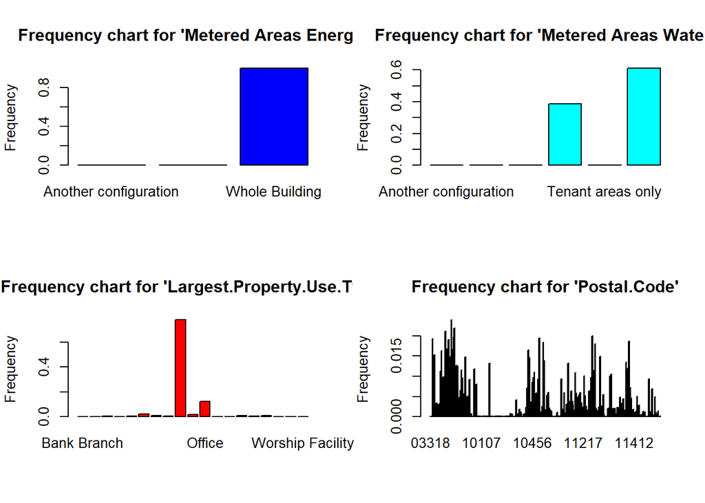

```r
#Bar Plot for Discrete Variables
par(mfrow=c(2,2))
barplot(prop.table(table(data_clean$Metered.Areas..Energy.)), ylab = "Frequency",
        main = "Frequency chart for 'Metered Areas Energy'", col = "blue")
barplot(prop.table(table(data_clean$Metered.Areas...Water.)), ylab = "Frequency",
        main = "Frequency chart for 'Metered Areas Water'", col = "Cyan")
barplot(prop.table(table(data_clean$Largest.Property.Use.Type)), ylab = "Frequency",
        main = "Frequency chart for 'Largest.Property.Use.Type'", col = "Red")
barplot(prop.table(table(data_clean$Postal.Code)), ylab = "Frequency",
        main = "Frequency chart for 'Postal.Code'", col = "Black")
```

```r
par(mfrow=c(1,1))
```

```r
#Cleaning Metered Areas Energy column
data_clean <- data_clean[which(data_clean$Metered.Areas..Energy. == "Whole Building"),]
data_clean$Metered.Areas..Energy. <- NULL
```

```r
#Cleaning 'Metered Area Water' column
data_clean <- data_clean[which(data_clean$Metered.Areas...Water. == "Not Available" | data_clean$Metered.Areas...Water. == "Whole Building"), ]
data_clean$Metered.Areas...Water. <- NULL
```

```r
#Cleaning 'Largest Property Use Type' column
table(data_clean$Largest.Property.Use.Type )
```

```
##
##                           Bank Branch                            Courthouse
##                                     2                                     2
##                   Distribution Center                      Financial Office
##                                    61                                    14
## Hospital (General Medical & Surgical)                                 Hotel
##                                    40                                   212
##                           K-12 School                        Medical Office
##                                    98                                    29
##                   Multifamily Housing            Non-Refrigerated Warehouse
##                                  7503                                   159
##                                Office                               Parking
##                                  1191                                     3
##                Refrigerated Warehouse              Residence Hall/Dormitory
##                                     9                                    96
##                          Retail Store                 Senior Care Community
##                                    64                                    92
##             Supermarket/Grocery Store            Wholesale Club/Supercenter
##                                    19                                     4
##                      Worship Facility
##                                     9
```

```r
data_clean <- data_clean[which(data_clean$Largest.Property.Use.Type == "Multifamily Housing" |
                                 data_clean$Largest.Property.Use.Type == "Office" |
                                 data_clean$Largest.Property.Use.Type == "Hotel" |
                                 data_clean$Largest.Property.Use.Type == "Non-Refrigerated Warehouse"),]
data_clean$Largest.Property.Use.Type <- factor(data_clean$Largest.Property.Use.Type)

str(data_clean)
```

```
## 'data.frame':    9065 obs. of  19 variables:
##  $ Postal.Code                                                : Factor w/ 231 levels "03318","10000",..: 139 139 40 40 40 21 29 216 216 216 ...
##  $ Largest.Property.Use.Type                                  : Factor w/ 4 levels "Hotel","Multifamily Housing",..: 2 2 2 2 2 2 2 2 2 2 ...
##  $ DOF.Benchmarking.Submission.Status                         : Factor w/ 2 levels "","In Compliance": 2 2 2 2 2 2 2 2 2 2 ...
##  $ Largest.Property.Use.Type...Gross.Floor.Area..ftÂ².        : num  412503 162656 321464 204720 116744 ...
##  $ Year.Built                                                 : num  1903 1903 1939 1939 1939 ...
##  $ Number.of.Buildings...Self.reported                        : num  2 1 2 1 1 2 2 4 6 4 ...
##  $ Occupancy                                                  : num  100 100 100 100 100 100 100 100 100 100 ...
##  $ Weather.Normalized.Site.EUI..kBtu.ftÂ².                    : num  NA 316.8 79.9 79 82.7 ...
##  $ Weather.Normalized.Site.Electricity.Intensity..kWh.ftÂ².   : num  7.5 5.8 3.5 4 2.6 6.1 10.7 7.4 4.9 12.4 ...
##  $ Weather.Normalized.Site.Natural.Gas.Intensity..therms.ftÂ².: num  0 3 0 0 0 0.5 0.2 0.3 0.1 0.2 ...
##  $ Weather.Normalized.Source.EUI..kBtu.ftÂ².                  : num  NA 374 106 109 103 ...
##  $ Natural.Gas.Use..kBtu.                                     : num  2047200 47522901 880200 553439 326761 ...
##  $ Weather.Normalized.Site.Natural.Gas.Use..therms.           : num  20472 512711 8906 5604 3302 ...
##  $ Electricity.Use...Grid.Purchase..kBtu.                     : num  11241926 3477065 3968642 2886852 1081789 ...
##  $ Direct.GHG.Emissions..Metric.Tons.CO2e.                    : num  151 2524 1525 936 589 ...
##  $ Indirect.GHG.Emissions..Metric.Tons.CO2e.                  : num  1043 323 368 268 100 ...
##  $ Property.GFA...Self.Reported..ftÂ².                        : num  432503 172656 321464 204720 116744 ...
##  $ Water.Intensity..All.Water.Sources...gal.ftÂ².             : num  51 NA 18.4 NA NA ...
##  $ ENERGY.STAR.Score                                          : num  93 1 72 67 80 100 40 67 99 12 ...
```

**Removing out lier from continuous variables and replacing missing values with average values**

```r
#Plot box plot for each continuous variable
par(mfrow=c(4,4))
ncol(data_clean)
```

```
## [1] 19
```

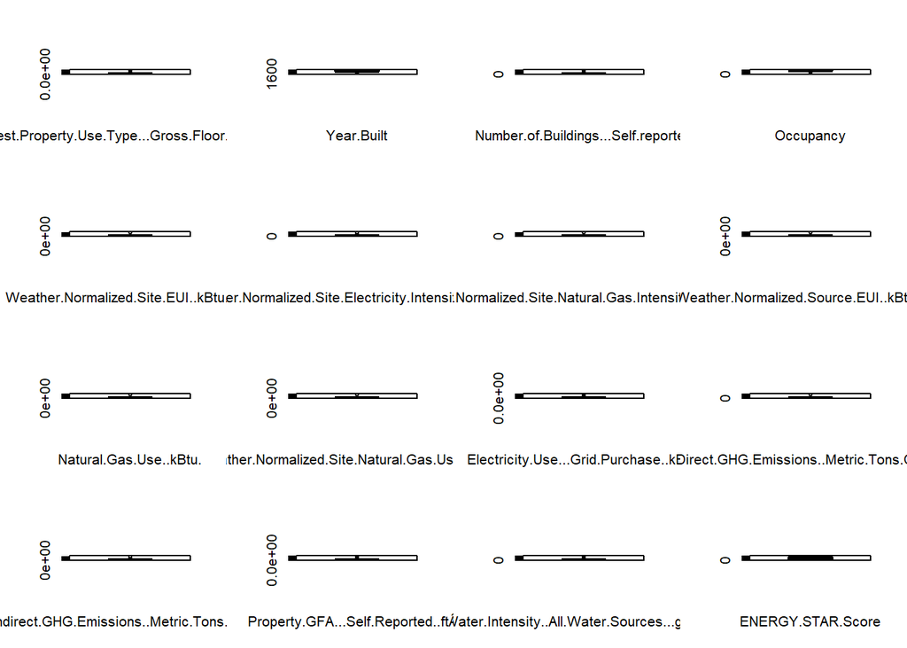

```r
for (i in 4:19){
  boxplot(data_clean[,i], xlab = colnames(data_clean)[i])
}
```

```r
par(mfrow=c(1,1))
```

```r
#Find absolute value of z-score for each value in each column
df <- data_clean[,4:19]
z_scores <- as.data.frame(sapply(df, function(df) (abs(df-mean(df, na.rm = TRUE))/sd(df, na.rm = TRUE))))
data_clean <- data_clean[!rowSums(z_scores>3, na.rm = TRUE), ]

for (i in 1:19){
  if(length(which(is.na(data_clean[,i]))=="TRUE")>0){
  data_clean[which(is.na(data_clean[,i])),i] <- median(data_clean[,i], na.rm = TRUE)
  }
}
rm(i)
rm(df)
```

**Correlation Matrix for feature selection**

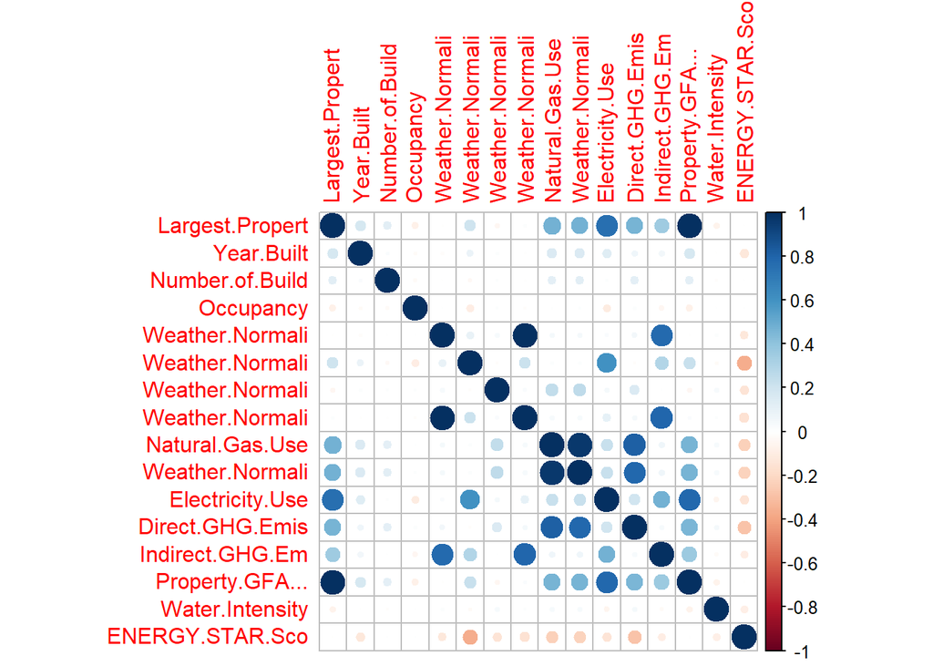

```r
cor_matrix <- data_clean
data_clean.cor <- cor(cor_matrix[4:19])
data_clean.cor.plot <- cor(cor_matrix[4:19])
colnames(data_clean.cor.plot) <- substring(colnames(data_clean[,4:19]),1,15)
rownames(data_clean.cor.plot) <- substring(colnames(data_clean[,4:19]),1,15)
corrplot(data_clean.cor.plot)
```

```r
highlyCorrelated <- findCorrelation(data_clean.cor, cutoff=0.75, names = TRUE)

#Removing highly correlated columns
data_clean <- data_clean[,-which(colnames(data_clean) %in% highlyCorrelated)]
```

**Renaming columns**

```r
length(colnames(data_clean))
```

```
## [1] 13
```

```r
names_col <- c("PostalCode","LargeUse", "SubmissionStatus",
                          "BuiltYear","CountofBuildings", "Occupancy",
                          "WeatherNormSiteEUI", "WeatherNormElecEUI", "WeatherNormNGEUI",
                          "ElecUse","DirectGHG","WaterIntensity","EnergyScore")
length(names_col)
```

```
## [1] 13
```

```r
colnames(data_clean) <- names_col
rm(names_col)
```

```r
#Remove duplicate entries
data_clean <- unique(data_clean)

str(data_clean)
```

```
## 'data.frame':    8729 obs. of  13 variables:
##  $ PostalCode        : Factor w/ 231 levels "03318","10000",..: 139 139 40 40 40 21 29 216 216 216 ...
##  $ LargeUse          : Factor w/ 4 levels "Hotel","Multifamily Housing",..: 2 2 2 2 2 2 2 2 2 2 ...
##  $ SubmissionStatus  : Factor w/ 2 levels "","In Compliance": 2 2 2 2 2 2 2 2 2 2 ...
##  $ BuiltYear         : num  1903 1903 1939 1939 1939 ...
##  $ CountofBuildings  : num  2 1 2 1 1 2 2 4 6 4 ...
##  $ Occupancy         : num  100 100 100 100 100 100 100 100 100 100 ...
##  $ WeatherNormSiteEUI: num  82.7 316.8 79.9 79 82.7 ...
##  $ WeatherNormElecEUI: num  7.5 5.8 3.5 4 2.6 6.1 10.7 7.4 4.9 12.4 ...
##  $ WeatherNormNGEUI  : num  0 3 0 0 0 0.5 0.2 0.3 0.1 0.2 ...
##  $ ElecUse           : num  11241926 3477065 3968642 2886852 1081789 ...
##  $ DirectGHG         : num  151 2524 1525 936 589 ...
##  $ WaterIntensity    : num  51 48 18.4 48 48 ...
##  $ EnergyScore       : num  93 1 72 67 80 100 40 67 99 12 ...
```

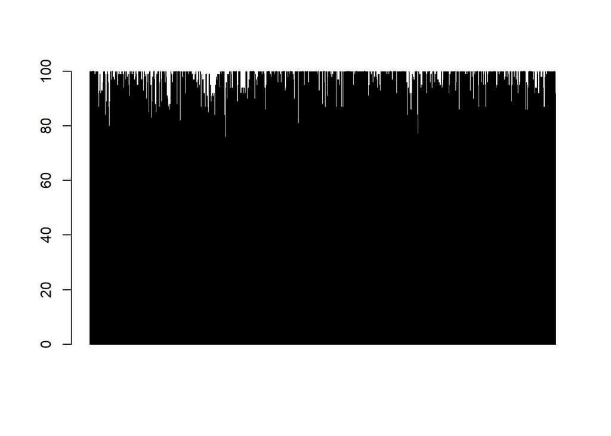

```r
#Visualizing the distribution of Target variable for any skewed distribution
barplot(data_clean$EnergyScore)
```

**Split data in train and test in 70-30**

```r
dt <- sort(sample(nrow(data_clean), nrow(data_clean)*.7))

train_data <- data_clean[dt,]
test_data <- data_clean[-dt,]
rm(dt)
```

**scaling variables for uniform range. As the range for EnergyScore is not much, we will scale only the X variables and not target variable**

```r
train_data[,4:12] <- scale(train_data[,4:12])
test_data[,4:12] <- scale(test_data[,4:12])
```

```r
#Removing the Submission Status column in train data. This column can later be used to predict only 'Not Submitted' Entries in test data

train_data_submission_col <- train_data$SubmissionStatus
train_data$SubmissionStatus <- NULL

test_data_submission_col <- test_data$SubmissionStatus
test_data$SubmissionStatus <- NULL

str(train_data)
```

```
## 'data.frame':    6110 obs. of  12 variables:
##  $ PostalCode        : Factor w/ 231 levels "03318","10000",..: 139 40 40 40 21 29 216 216 216 27 ...
##  $ LargeUse          : Factor w/ 4 levels "Hotel","Multifamily Housing",..: 2 2 2 2 2 2 2 2 2 4 ...
##  $ BuiltYear         : num  -1.541 -0.294 -0.294 -0.294 -1.264 ...
##  $ CountofBuildings  : num  -0.128 1.413 -0.128 -0.128 1.413 ...
##  $ Occupancy         : num  0.228 0.228 0.228 0.228 0.228 ...
##  $ WeatherNormSiteEUI: num  5.7229 -0.1468 -0.1691 -0.0774 -0.0774 ...
##  $ WeatherNormElecEUI: num  -0.1492 -0.5563 -0.4678 -0.7156 -0.0961 ...
##  $ WeatherNormNGEUI  : num  6.306761 -1.260312 -1.260312 -1.260312 0.000867 ...
##  $ ElecUse           : num  -0.0462 0.0265 -0.1336 -0.4006 0.0332 ...
##  $ DirectGHG         : num  4.58 2.434 1.17 0.423 0.179 ...
##  $ WaterIntensity    : num  -0.127 -0.55 -0.127 -0.127 -0.127 ...
##  $ EnergyScore       : num  1 72 67 80 100 40 99 12 88 100 ...
```